# Time Series 00: Intro to Time Series Data in R - Managing Date/Time Formats & Simple Plots using ggplot2

This tutorial will demonstrate how to import a time series dataset stored in `.csv` format into R. It will explore data classes for columns in a `data.frame` and will walk through how to convert a date, stored as a character string, into a date class that R can recognize and plot efficiently.

## Learning Objectives

After completing this tutorial, you will be able to:

- Open a `.csv` file in R using `read.csv()`and understand why we are using that file type.
- Work with data stored in different columns within a `data.frame` in R.
- Examine R object structures and data `classes`.
- Convert dates, stored as a character class, into an R date class.
- Create a quick plot of a time-series dataset using `qplot`.

## Things You’ll Need To Complete This Tutorial

You will need the most current version of R and, preferably, RStudio loaded on your computer to complete this tutorial.

### Install R Packages

- **ggplot2:** `install.packages("ggplot2")`

[More on Packages in R](https://www.neonscience.org/packages-in-r) – Adapted from Software Carpentry.

## Download Data

### [NEON Teaching Data Subset: Meteorological Data for Harvard Forest](https://ndownloader.figshare.com/files/3701572)

The data used in this lesson were collected at the [National Ecological Observatory Network’s](https://www.neonscience.org/) [Harvard Forest field site](https://www.neonscience.org/field-sites/field-sites-map/HARV). These data are proxy data for what will be available for 30 years on the [NEON data portal](http://data.neonscience.org/) for the Harvard Forest and other field sites located across the United States.

[Download Dataset](https://ndownloader.figshare.com/files/3701572)

**Set Working Directory:** This lesson assumes that you have set your working directory to the location of the downloaded and unzipped data subsets.

[An overview of setting the working directory in R can be found here.](https://www.neonscience.org/set-working-directory-r)

**R Script & Challenge Code:** NEON data lessons often contain challenges that reinforce learned skills. If available, the code for challenge solutions is found in the downloadable R script of the entire lesson, available in the footer of each lesson page.

## Data Related to Phenology

In this tutorial, we will explore atmospheric data (including temperature, precipitation and other metrics) collected by sensors mounted on a [flux tower](https://www.neonscience.org/data-collection/flux-tower-measurements) at the NEON Harvard Forest field site. We are interested in exploring changes in temperature, precipitation, Photosynthetically Active Radiation (PAR) and day length throughout the year – metrics that impact changes in the timing of plant [phenophases (phenology)](http://budburst.org/phenology-defined#what-is-phenology).

## About .csv Format

The data that we will use is in `.csv` (comma-separated values) file format. The `.csv` format is a plain text format, where each value in the dataset is separate by a comma and each “row” in the dataset is separated by a line break. Plain text formats are ideal for working both across platforms (Mac, PC, LINUX, etc) and also can be read by many different tools. The plain text format is also less likely to become obsolete over time.

**Data Tip:** [For more on .csv format see this Wikipedia article.](https://en.wikipedia.org/wiki/Comma-separated_values)

## Import the Data

To begin, let’s import the data into R. We can use base R functionality to import a `.csv` file. We will use the `ggplot2` package to plot our data.

```r
# Load packages required for entire script.
# library(PackageName)  # purpose of package
library(ggplot2)   # efficient, pretty plotting - required for qplot function

# set working directory to ensure R can find the file we wish to import
# provide the location for where you've unzipped the lesson data
wd <- "~/Documents/"
```

**Data Tip:** Good coding practice – install and load all libraries at top of script. If you decide you need another package later on in the script, return to this area and add it. That way, with a glance, you can see all packages used in a given script.

Once our working directory is set, we can import the file using `read.csv()`.

```r
# Load csv file of daily meteorological data from Harvard Forest
harMet.daily <- read.csv(
      file=paste0(wd,"NEON-DS-Met-Time-Series/HARV/FisherTower-Met/hf001-06-daily-m.csv"),
      stringsAsFactors = FALSE
      )
```

### stringsAsFactors=FALSE

When reading in files we most often use `stringsAsFactors = FALSE`. This setting ensures that non-numeric data (strings) are not converted to factors.

#### What Is A Factor?

A factor is similar to a category. However factors can be numerically interpreted (they can have an order) and may have a level associated with them.

Examples of factors:

- **Month Names (an ordinal variable):** Month names are non-numerical but we know that April (month 4) comes after March (month 3) and each could be represented by a number (4 & 3).
- **1 and 2s to represent male and female sex (a nominal variable):** Numerical interpretation of non-numerical data but no order to the levels.

**Data Tip:** [Read more about factors here.](http://www.stat.berkeley.edu/~s133/factors.html)

After loading the data it is easy to convert any field that should be a factor by using `as.factor()`. Therefore it is often best to read in a file with `stringsAsFactors = FALSE`.

## Data.Frames in R

The `read.csv()` imports our `.csv` into a `data.frame` object in R. `data.frames` are ideal for working with tabular data - they are similar to a spreadsheet.

```r
# what type of R object is our imported data?
class(harMet.daily)
```

```
## [1] "data.frame"
```

## Data Structure

Once the data are imported, we can explore their structure. There are several ways to examine the structure of a data frame:

- `head()`: shows us the first 6 rows of the data (`tail()` shows the last 6 rows).
- `str()` : displays the structure of the data as R interprets it.

Let’s use both to explore our data.

```r
# view first 6 rows of the dataframe
head(harMet.daily)
```

```
##         date jd  airt f.airt airtmax f.airtmax airtmin f.airtmin rh f.rh rhmax
## 1 2001-02-11 42 -10.7           -6.9             -15.1           40         58
## 2 2001-02-12 43  -9.8           -2.4             -17.4           45         85
## 3 2001-02-13 44  -2.0            5.7              -7.3           70        100
## 4 2001-02-14 45  -0.5            1.9              -5.7           78        100
## 5 2001-02-15 46  -0.4            2.4              -5.7           69        100
## 6 2001-02-16 47  -3.0            1.3              -9.0           82        100
##   f.rhmax rhmin f.rhmin  dewp f.dewp dewpmax f.dewpmax dewpmin f.dewpmin prec
## 1            22         -22.2          -16.8             -25.7            0.0
## 2            14         -20.7           -9.2             -27.9            0.0
## 3            34          -7.6           -4.6             -10.2            0.0
## 4            59          -4.1            1.9             -10.2            6.9
## 5            37          -6.0            2.0             -12.1            0.0
## 6            46          -5.9           -0.4             -10.6            2.3
##   f.prec slrt f.slrt part f.part netr f.netr  bar f.bar wspd f.wspd wres f.wres
```

[output cut: 20 more lines]

```r
# View the structure (str) of the data
str(harMet.daily)
```

```
## 'data.frame':    5345 obs. of  46 variables:
##  $ date     : chr  "2001-02-11" "2001-02-12" "2001-02-13" "2001-02-14" ...
##  $ jd       : int  42 43 44 45 46 47 48 49 50 51 ...
##  $ airt     : num  -10.7 -9.8 -2 -0.5 -0.4 -3 -4.5 -9.9 -4.5 3.2 ...
##  $ f.airt   : chr  "" "" "" "" ...
##  $ airtmax  : num  -6.9 -2.4 5.7 1.9 2.4 1.3 -0.7 -3.3 0.7 8.9 ...
##  $ f.airtmax: chr  "" "" "" "" ...
##  $ airtmin  : num  -15.1 -17.4 -7.3 -5.7 -5.7 -9 -12.7 -17.1 -11.7 -1.3 ...
##  $ f.airtmin: chr  "" "" "" "" ...
##  $ rh       : int  40 45 70 78 69 82 66 51 57 62 ...
##  $ f.rh     : chr  "" "" "" "" ...
##  $ rhmax    : int  58 85 100 100 100 100 100 71 81 78 ...
##  $ f.rhmax  : chr  "" "" "" "" ...
##  $ rhmin    : int  22 14 34 59 37 46 30 34 37 42 ...
##  $ f.rhmin  : chr  "" "" "" "" ...
```

[output cut: 32 more lines]

**Data Tip:** You can adjust the number of rows returned when using the `head()` and `tail()` functions. For example you can use `head(harMet.daily, 10)` to display the first 10 rows of your data rather than 6.

### Classes in R

The structure results above let us know that the attributes in our `data.frame` are stored as several different data types or `classes` as follows:

- **chr - Character:** It holds strings that are composed of letters and words. Character class data can not be interpreted numerically - that is to say we can not perform math on these values even if they contain only numbers.
- **int - Integer:** It holds numbers that are whole integers without decimals. Mathematical operations can be performed on integers.
- **num - Numeric:** It accepts data that are a wide variety of numeric formats including decimals (floating point values) and integers. Numeric also accept larger numbers than **int** will.

Storing variables using different `classes` is a strategic decision by R (and other programming languages) that optimizes processing and storage. It allows:

- data to be processed more quickly & efficiently.
- the program (R) to minimize the storage size.

### Differences Between Classes

Certain functions can be performed on certain data classes and not on others.

For example:

```r
a <- "mouse"
b <- "sparrow"
class(a)
```

```
## [1] "character"
```

```r
class(b)
```

```
## [1] "character"
```

```r
# subract a-b
a-b
```

```
## Error in a - b: non-numeric argument to binary operator
```

You can not subtract two **character** values given they are not numbers.

```r
c <- 2
d <- 1
class(c)
```

```
## [1] "numeric"
```

```r
class(d)
```

```
## [1] "numeric"
```

```r
# subract a-b
c-d
```

```
## [1] 1
```

Additionally, performing summary statistics and other calculations of different types of classes can yield different results.

```r
# create a new object
speciesObserved <- c("speciesb","speciesc","speciesa")
speciesObserved
```

```
## [1] "speciesb" "speciesc" "speciesa"
```

```r
# determine the class
class(speciesObserved)
```

```
## [1] "character"
```

```r
# calculate the minimum
min(speciesObserved)
```

```
## [1] "speciesa"
```

```r
# create numeric object
prec <- c(1,2,5,3,6)
# view class
class(prec)
```

```
## [1] "numeric"
```

```r
# calculate min value
min(prec)
```

```
## [1] 1
```

We can calculate the minimum value for `SpeciesObserved`, a **character** data class, however it does not return a quantitative minimum. It simply looks for the first element, using alphabetical (rather than numeric) order. Yet, we can calculate the quantitative minimum value for `prec` a **numeric** data class.

## Plot Data Using qplot()

Now that we’ve got classes down, let’s plot one of the metrics in our data, air temperature – `airt`. Given this is a time series dataset, we want to plot air temperature as it changes over time. We have a date-time column, `date`, so let’s use that as our x-axis variable and `airt` as our y-axis variable.

We will use the `qplot()` (for *quick plot*) function in the `ggplot2` package. The syntax for `qplot()` requires the x- and y-axis variables and then the R object that the variables are stored in.

**Data Tip:** Add a title to the plot using `main="Title string"`.

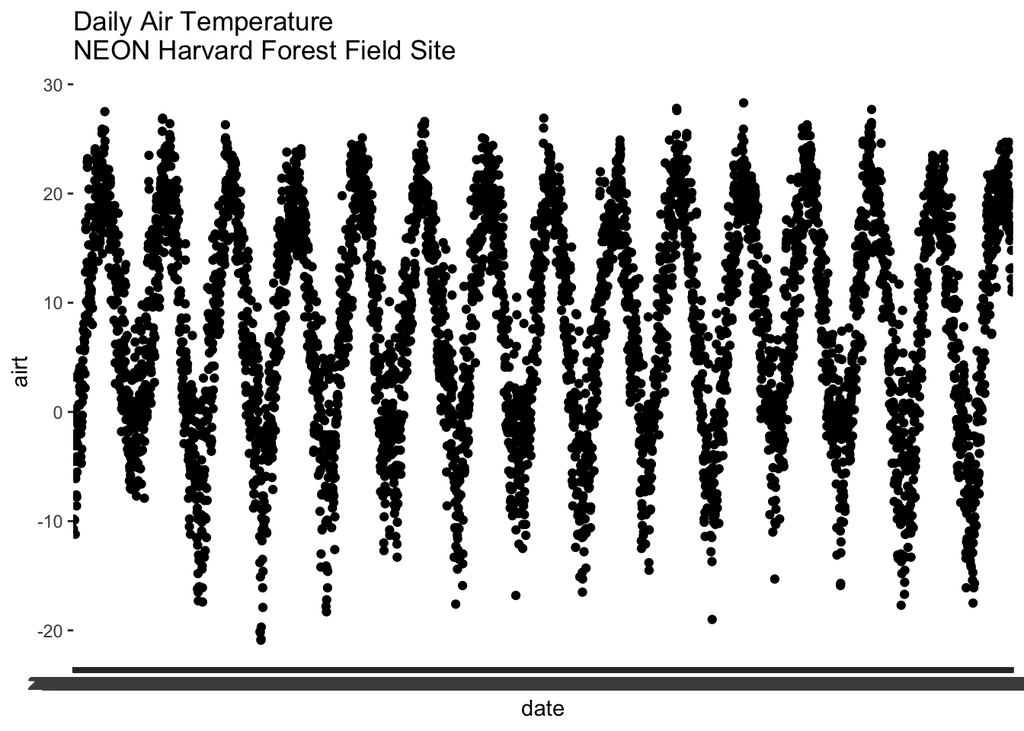

```r
# quickly plot air temperature
qplot(x=date, y=airt,
      data=harMet.daily,
      main="Daily Air Temperature\nNEON Harvard Forest Field Site")
```

We have successfully plotted some data. However, what is happening on the x-axis?

R is trying to plot EVERY date value in our data, on the x-axis. This makes it hard to read. Why? Let’s have a look at the class of the x-axis variable - date.

```r
# View data class for each column that we wish to plot
class(harMet.daily$date)
```

```
## [1] "character"
```

```r
class(harMet.daily$airt)
```

```
## [1] "numeric"
```

In this case, the `date` column is stored in our `data.frame` as a character class. Because it is a character, R does not know how to plot the dates as a continuous variable. Instead it tries to plot every date value as a text string. The `airt` data class is numeric so that metric plots just fine.

## Date as a Date-Time Class

We need to convert our `date` column, which is currently stored as a character to a `date-time` class that can be displayed as a continuous variable. Lucky for us, R has a `date` class. We can convert the `date` field to a `date class` using `as.Date()`.

```r
# convert column to date class
harMet.daily$date <- as.Date(harMet.daily$date)

# view R class of data
class(harMet.daily$date)
```

```
## [1] "Date"
```

```r
# view results
head(harMet.daily$date)
```

```
## [1] "2001-02-11" "2001-02-12" "2001-02-13" "2001-02-14" "2001-02-15"
## [6] "2001-02-16"
```

Now that we have adjusted the date, let’s plot again. Notice that it plots much more quickly now that R recognizes `date` as a date class. R can aggregate ticks on the x-axis by year instead of trying to plot every day!

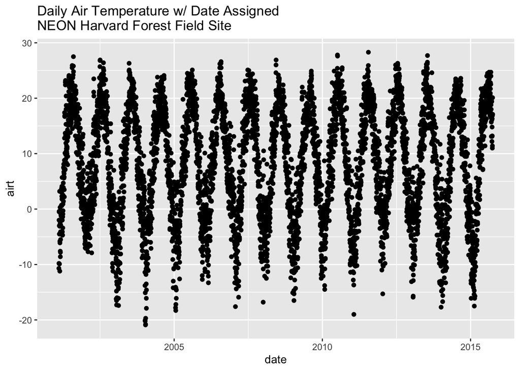

Relationship Between Daily Air Temperature and Time at Harvard Forest Research Site

```r
# quickly plot the data and include a title using main=""
# In title string we can use '\n' to force the string to break onto a new line
qplot(x=date,y=airt,
      data=harMet.daily,
      main="Daily Air Temperature w/ Date Assigned\nNEON Harvard Forest Field Site")
```

### Challenge: Using ggplot2’s qplot function

1. Create a quick plot of the precipitation. Use the full time frame of data available in the `harMet.daily` object.
2. Do precipitation and air temperature have similar annual patterns?
3. Create a quick plot examining the relationship between air temperature and precipitation.

Hint: you can modify the X and Y axis labels using `xlab="label text"` and `ylab="label text"`.

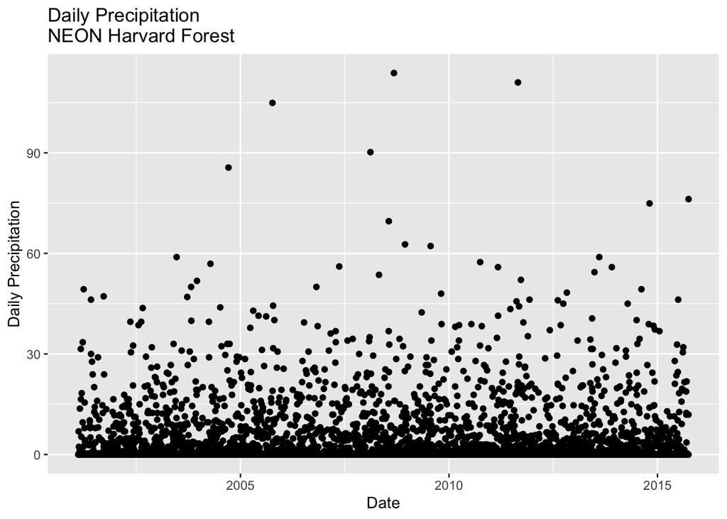

Relationship Between Daily Precipitation and Time at Harvard Forest Research Site

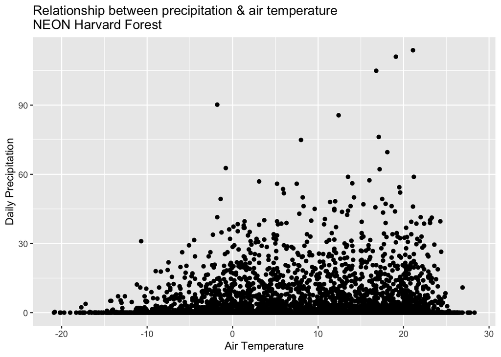

Relationship Between Daily Precipitation and Daily Air Temperature at Harvard Forest Research Site